# Datasets_in_R

Download and load the dataset from: `https://git.embl.de/hsanchez/BTM2016_RDatasets/raw/master/bodyfat.csv`

```r
download.file("https://git.embl.de/hsanchez/BTM2016_RDatasets/raw/master/bodyfat.csv", "bodyfat.csv")

bodyfat<-read.csv("bodyfat.csv")
```

Explore the dataset:

```r
# Firts lines
head(bodyfat)
```

```
##   X density percent.fat age weight height neck.circum chest.circum
## 1 1  1.0708        12.3  23 154.25  67.75        36.2         93.1
## 2 2  1.0853         6.1  22 173.25  72.25        38.5         93.6
## 3 3  1.0414        25.3  22 154.00  66.25        34.0         95.8
## 4 4  1.0751        10.4  26 184.75  72.25        37.4        101.8
## 5 5  1.0340        28.7  24 184.25  71.25        34.4         97.3
## 6 6  1.0502        20.9  24 210.25  74.75        39.0        104.5
##   abdomen.circum hip.circum thigh.circum knee.circum ankle.circum
## 1           85.2       94.5         59.0        37.3         21.9
## 2           83.0       98.7         58.7        37.3         23.4
## 3           87.9       99.2         59.6        38.9         24.0
## 4           86.4      101.2         60.1        37.3         22.8
## 5          100.0      101.9         63.2        42.2         24.0
## 6           94.4      107.8         66.0        42.0         25.6
##   bicep.circum forearm.circum wrist.circum
## 1         32.0           27.4         17.1
## 2         30.5           28.9         18.2
## 3         28.8           25.2         16.6
## 4         32.4           29.4         18.2
## 5         32.2           27.7         17.7
## 6         35.7           30.6         18.8
```

```r
# Names of the columns
names(bodyfat)
```

```
##  [1] "X"              "density"        "percent.fat"    "age"
##  [5] "weight"         "height"         "neck.circum"    "chest.circum"
##  [9] "abdomen.circum" "hip.circum"     "thigh.circum"   "knee.circum"
## [13] "ankle.circum"   "bicep.circum"   "forearm.circum" "wrist.circum"
```

Brief explanation of the values:

- Density determined from underwater weighing
- Percent body fat from Siri’s (1956) equation
- Age (years)
- Weight (lbs)
- Height (inches)
- Neck circumference (cm)
- Chest circumference (cm)
- Abdomen 2 circumference (cm)
- Hip circumference (cm)
- Thigh circumference (cm)
- Knee circumference (cm)
- Ankle circumference (cm)
- Biceps (extended) circumference (cm)
- Forearm circumference (cm)
- Wrist circumference (cm)

Lets continue exploring the dataset

```r
# Dimensions
dim(bodyfat)
```

```
## [1] 252  16
```

```r
# Checking only one column, try the TAB key
bodyfat$age
```

```
##   [1] 23 22 22 26 24 24 26 25 25 23 26 27 32 30 35 35 34 32 28 33 28 28 31
##  [24] 32 28 27 34 31 27 29 32 29 27 41 41 49 40 50 46 50 45 44 48 41 39 43
##  [47] 40 39 45 47 47 40 51 49 42 54 58 62 54 61 62 56 54 61 57 55 54 55 54
##  [70] 55 62 55 56 55 61 61 57 69 81 66 67 64 64 70 72 67 72 64 46 48 46 44
##  [93] 47 46 47 53 38 50 46 47 49 48 41 49 43 43 43 52 43 40 43 43 47 42 48
## [116] 40 48 51 40 44 52 44 40 47 50 46 42 43 40 42 49 40 47 50 41 44 39 43
## [139] 40 49 40 40 52 23 23 24 24 25 25 26 26 26 27 27 27 28 28 28 30 31 31
## [162] 33 33 34 34 35 35 35 35 35 35 35 35 36 36 37 37 37 38 39 39 40 40 40
## [185] 40 40 41 41 41 41 41 42 42 42 42 42 42 42 42 43 43 43 43 44 44 44 44
## [208] 47 47 47 49 49 49 50 50 51 51 51 52 53 54 54 54 55 55 55 55 55 56 56
## [231] 57 57 58 58 60 62 62 63 64 65 65 65 66 67 67 68 69 70 72 72 72 74
```

```r
head( bodyfat[ ,4] )
```

```
## [1] 23 22 22 26 24 24
```

```r
head( bodyfat[ ,4], 12 )
```

```
##  [1] 23 22 22 26 24 24 26 25 25 23 26 27
```

```r
# Numeric values describing age
summary(bodyfat$age)
```

```
##    Min. 1st Qu.  Median    Mean 3rd Qu.    Max.
##   22.00   35.75   43.00   44.88   54.00   81.00
```

```r
# Getting the mean of the age values
summary(bodyfat$age)[4]
```

```
##  Mean
## 44.88
```

```r
mean(bodyfat$age)
```

```
## [1] 44.88492
```

```r
# How many are younger than 31 years old?
younger_than_31 <- bodyfat[ (bodyfat$age < 31), ]
length(younger_than_31)
```

```
## [1] 16
```

```r
# Another way
not_older_than_30 <- bodyfat[ !(bodyfat$age > 30), ]
length(not_older_than_30)
```

```
## [1] 16
```

```r
# Watch out!
head( bodyfat[  !(bodyfat$age  > 30), ] )
```

```
##   X density percent.fat age weight height neck.circum chest.circum
## 1 1  1.0708        12.3  23 154.25  67.75        36.2         93.1
## 2 2  1.0853         6.1  22 173.25  72.25        38.5         93.6
## 3 3  1.0414        25.3  22 154.00  66.25        34.0         95.8
## 4 4  1.0751        10.4  26 184.75  72.25        37.4        101.8
## 5 5  1.0340        28.7  24 184.25  71.25        34.4         97.3
## 6 6  1.0502        20.9  24 210.25  74.75        39.0        104.5
##   abdomen.circum hip.circum thigh.circum knee.circum ankle.circum
## 1           85.2       94.5         59.0        37.3         21.9
## 2           83.0       98.7         58.7        37.3         23.4
## 3           87.9       99.2         59.6        38.9         24.0
## 4           86.4      101.2         60.1        37.3         22.8
## 5          100.0      101.9         63.2        42.2         24.0
## 6           94.4      107.8         66.0        42.0         25.6
##   bicep.circum forearm.circum wrist.circum
## 1         32.0           27.4         17.1
## 2         30.5           28.9         18.2
## 3         28.8           25.2         16.6
## 4         32.4           29.4         18.2
## 5         32.2           27.7         17.7
## 6         35.7           30.6         18.8
```

```r
head( bodyfat[  !which(bodyfat$age  > 30), ] )
```

```
##  [1] X              density        percent.fat    age
##  [5] weight         height         neck.circum    chest.circum
##  [9] abdomen.circum hip.circum     thigh.circum   knee.circum
## [13] ankle.circum   bicep.circum   forearm.circum wrist.circum
## <0 rows> (or 0-length row.names)
```

```r
## not equivalent!
```

Getting the mean of all the values

Using a ‘for’ loop

```r
number_of_columns <- length(names(bodyfat))
number_of_columns <- dim(bodyfat)[2]
my_vector <- vector(length = number_of_columns)
for( i in 1:length( names(bodyfat) ) ){
    one_column <- bodyfat[ ,i]
    the_mean <- mean(one_column)
    my_vector[i] <- the_mean
}
names(my_vector) <- names(bodyfat)

my_vector
```

```
##              X        density    percent.fat            age         weight
##     126.500000       1.055574      19.150794      44.884921     178.924405
##         height    neck.circum   chest.circum abdomen.circum     hip.circum
##      70.148810      37.992063     100.824206      92.555952      99.904762
##   thigh.circum    knee.circum   ankle.circum   bicep.circum forearm.circum
##      59.405952      38.590476      23.102381      32.273413      28.663889
##   wrist.circum
##      18.229762
```

Using the function ‘apply()’

```r
apply(bodyfat, MARGIN = 2, FUN = mean)
```

```
##              X        density    percent.fat            age         weight
##     126.500000       1.055574      19.150794      44.884921     178.924405
##         height    neck.circum   chest.circum abdomen.circum     hip.circum
##      70.148810      37.992063     100.824206      92.555952      99.904762
##   thigh.circum    knee.circum   ankle.circum   bicep.circum forearm.circum
##      59.405952      38.590476      23.102381      32.273413      28.663889
##   wrist.circum
##      18.229762
```

Is `apply()` really better than `for()`

```r
usingFor <- function(){
  my_vector <- vector(length = number_of_columns)
  for( i in 1:length( names(bodyfat) ) ){
    one_column <- bodyfat[ ,i]
    the_mean <- mean(one_column)
    my_vector[i] <- the_mean
  }
  names(my_vector) <- names(bodyfat)
}
usingApply <- function(){
  temp <- apply(bodyfat, MARGIN = 2, FUN = mean)
}

system.time(replicate(1000000, usingFor))
```

```
##    user  system elapsed
##   0.423   0.013   0.442
```

```r
system.time(replicate(1000000, usingApply))
```

```
##    user  system elapsed
##   0.394   0.007   0.404
```

```r
library(pryr)
mem_change(v <- 1:1e6)
```

```
## 4.01 MB
```

```r
mem_change(rm(v))
```

```
## -4 MB
```

```r
try(rm(new_variable))
mem_change(new_variable <- bodyfat$age)
```

```
## 1.08 kB
```

```r
# Going back!

apply(bodyfat, MARGIN = 2, FUN = mean)
```

```
##              X        density    percent.fat            age         weight
##     126.500000       1.055574      19.150794      44.884921     178.924405
##         height    neck.circum   chest.circum abdomen.circum     hip.circum
##      70.148810      37.992063     100.824206      92.555952      99.904762
##   thigh.circum    knee.circum   ankle.circum   bicep.circum forearm.circum
##      59.405952      38.590476      23.102381      32.273413      28.663889
##   wrist.circum
##      18.229762
```

19 percent fat is quite high.

What if this value is age-depentent?

Subset_1: younger than 31 yo

Subset_2: older than 30 yo but younger than 51 yo

Subset_3: older than 50 yo

Option 1: generating many variables

```r
Subset_1_indexes<-which(bodyfat$age < 31)
Subset_1<-bodyfat[Subset_1_indexes, ]

# Getting the 30+
temp_indexes<-which(bodyfat$age > 30)
Subset30plus<-bodyfat[temp_indexes, ]

Subset_2_indexes<-which(Subset30plus$age < 51)
Subset_2<-Subset30plus[Subset_2_indexes, ]

Subset_3_indexes<-which(Subset30plus$age > 50)
Subset_3<-Subset30plus[Subset_3_indexes, ]

summary(Subset_2$age)
```

```
##    Min. 1st Qu.  Median    Mean 3rd Qu.    Max.
##    31.0    39.0    42.0    41.7    46.0    50.0
```

```r
summary(Subset_3$age)
```

```
##    Min. 1st Qu.  Median    Mean 3rd Qu.    Max.
##   51.00   54.75   58.00   60.08   65.00   81.00
```

```r
# Finally, getting the weight per Subset:
mean(Subset_1$percent.fat)
```

```
## [1] 14.36842
```

```r
mean(Subset_2$percent.fat)
```

```
## [1] 19.38913
```

```r
mean(Subset_3$percent.fat)
```

```
## [1] 21.10921
```

Can we make the same in a bit less lines?

```r
# Young people
mean( bodyfat[  bodyfat$age < 31, ]$percent.fat )
```

```
## [1] 14.36842
```

```r
# Not so young people
mean( bodyfat[  bodyfat$age > 30 & bodyfat$age < 51, ]$percent.fat )
```

```
## [1] 19.38913
```

```r
# Definitely not young people
mean( bodyfat[  bodyfat$age > 50, ]$percent.fat )
```

```
## [1] 21.10921
```

Is it really convenient to write long lines instead of asigning several variables?

```r
Option1<-function(){
  Subset_1_indexes<-which(bodyfat$age < 31)
  Subset_1<-bodyfat[Subset_1_indexes, ]
  temp_indexes<-which(bodyfat$age > 30)
  Subset30plus<-bodyfat[temp_indexes, ]
  Subset_2_indexes<-which(Subset30plus$age < 51)
  Subset_2<-Subset30plus[Subset_2_indexes, ]
  Subset_3_indexes<-which(Subset30plus$age > 50)
  Subset_3<-Subset30plus[Subset_3_indexes, ]
  summary(Subset_2$age)
  summary(Subset_3$age)
  mean(Subset_1$percent.fat)
  mean(Subset_2$percent.fat)
  mean(Subset_3$percent.fat)
}

Option2<-function(){
  mean( bodyfat[  bodyfat$age < 31, ]$percent.fat )
  mean( bodyfat[  bodyfat$age > 30 & bodyfat$age < 51, ]$percent.fat )
  mean( bodyfat[  bodyfat$age > 50, ]$percent.fat )
}

system.time(replicate(1000000, Option1))
```

```
##    user  system elapsed
##   0.427   0.003   0.433
```

```r
system.time(replicate(1000000, Option2))
```

```
##    user  system elapsed
##   0.392   0.002   0.396
```

So there was a difference!

What about the other measurements, maybe there was another one with a stronger correlation.

Lets keep using apply functions to find all paired correlations with the age value.

```r
# Which columns are not the index, nor the age?
I_do_not_want_these_ones<-which(names(bodyfat)==c("X", "age"))
names(bodyfat[-I_do_not_want_these_ones])
```

```
##  [1] "density"        "percent.fat"    "weight"         "height"
##  [5] "neck.circum"    "chest.circum"   "abdomen.circum" "hip.circum"
##  [9] "thigh.circum"   "knee.circum"    "ankle.circum"   "bicep.circum"
## [13] "forearm.circum" "wrist.circum"
```

```r
# I calculate the pearson correlations of age and all the other values
sapply(bodyfat[-I_do_not_want_these_ones], function(x){
  cor(bodyfat$age, x)
})
```

```
##        density    percent.fat         weight         height    neck.circum
##    -0.27763721     0.29145844    -0.01274609    -0.17164514     0.11350519
##   chest.circum abdomen.circum     hip.circum   thigh.circum    knee.circum
##     0.17644968     0.23040942    -0.05033212    -0.20009576     0.01751569
##   ankle.circum   bicep.circum forearm.circum   wrist.circum
##    -0.10505810    -0.04116212    -0.08505555     0.21353062
```

How would this two variables (density and percent of fat) would correlate?

```r
cor(bodyfat$percent.fat, bodyfat$density)
```

```
## [1] -0.9877824
```

Lets see how the values look like in an xy plot:

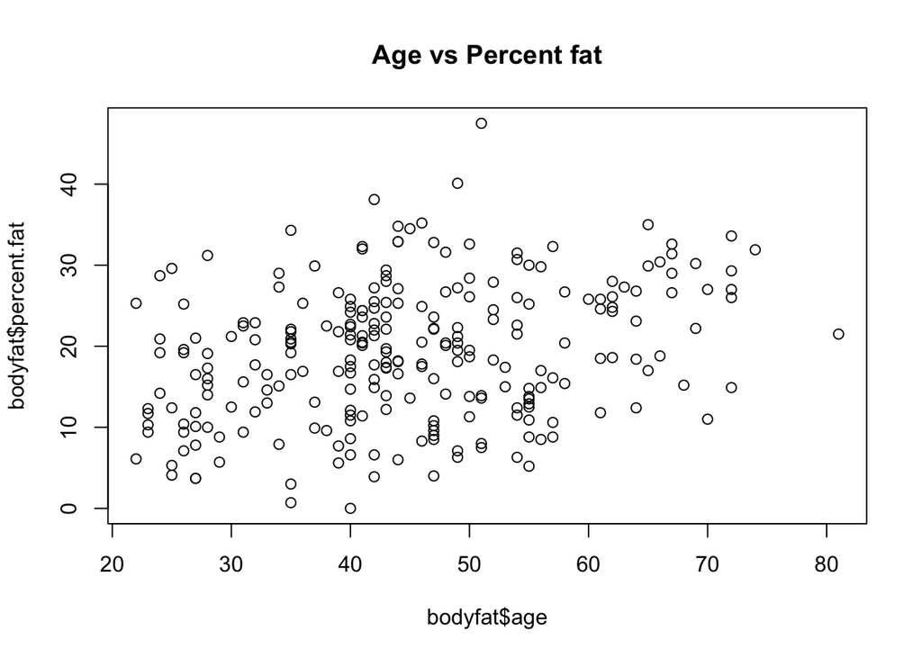

```r
plot(bodyfat$age, bodyfat$percent.fat, main="Age vs Percent fat")
```

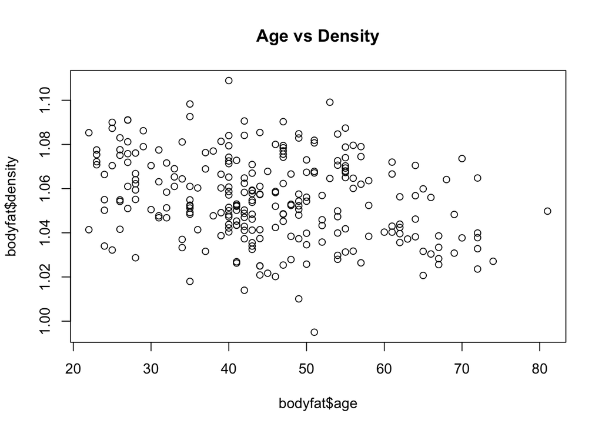

```r
plot(bodyfat$age, bodyfat$density, main="Age vs Density")
```

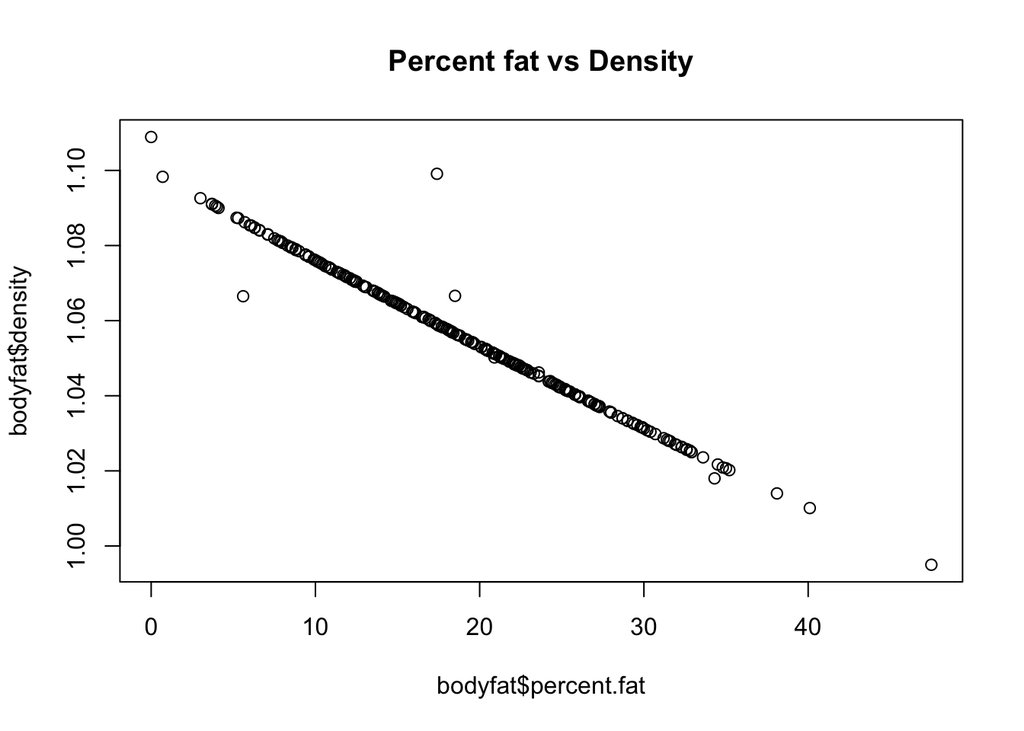

```r
plot(bodyfat$percent.fat, bodyfat$density, main="Percent fat vs Density")
```

Are we missing any other interesting correlation:

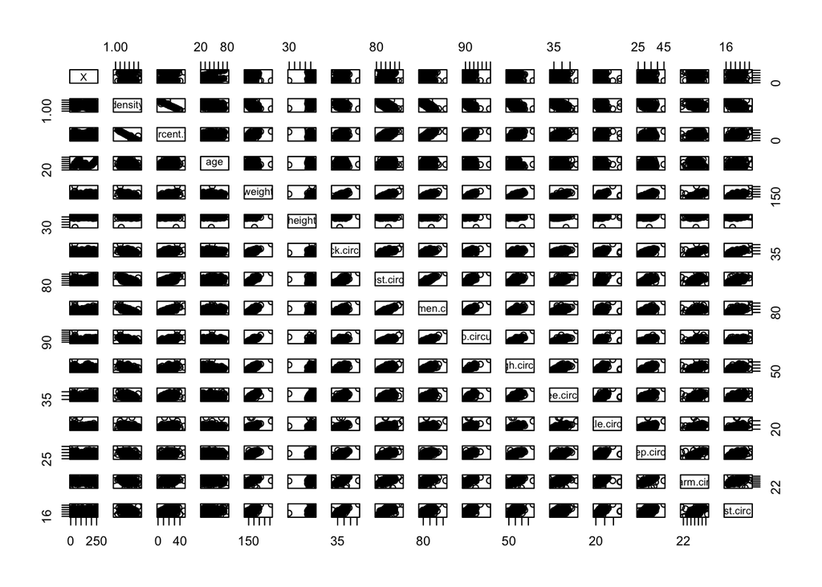

```r
pairs(bodyfat)
```

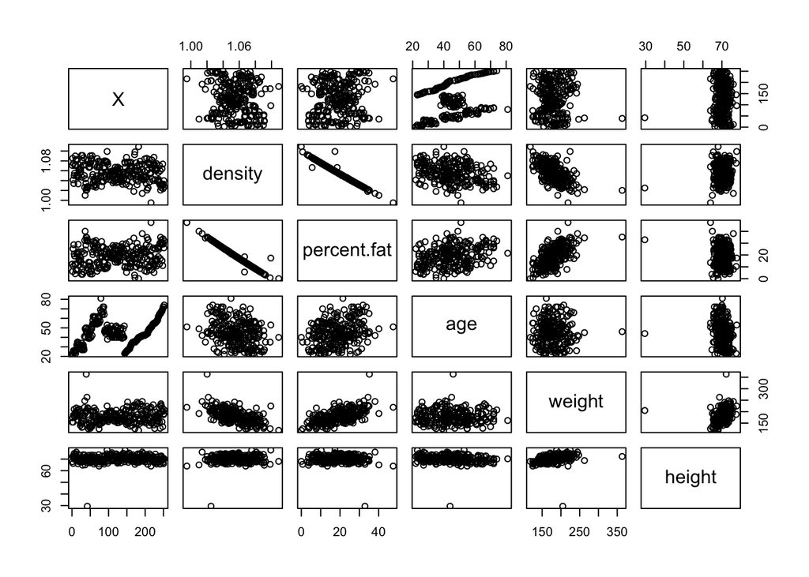

```r
pairs(bodyfat[ , 1:6])
```

## Fail but fast and loudly

```r
message("Your code is talking to you")
```

```
## Your code is talking to you
```

```r
#for(i in c(2, 1, 0, -1)){
#  sqrt(i)
#}

for(i in c(2, 1, 0, -1)){
  if(i >= 0){
    sqrt(i)
    print(i)
  }
}
```

```
## [1] 2
## [1] 1
## [1] 0
```

```r
# Trying to calculate the mean of the columns 4th, 3rd, and 17th
# Unknown vector
UnknownVector <- c(c(4, 3, 17))
#sapply( UnknonwVector, function(x){
#  mean(bodyfat[, x])
#})

# bodyfat[ ,17]

# Lets prevent to have an error:
# option 1:
sapply( UnknownVector, function(x){
  try(mean(bodyfat[, x]))
} )
```

```
## [1] "44.8849206349206"
## [2] "19.1507936507937"
## [3] "Error in `[.data.frame`(bodyfat, , x) : undefined columns selected\n"
```

```r
# Option 2:
sapply( UnknownVector[ which( UnknownVector %in% 1:dim(bodyfat)[2] ) ], function(x){
  mean( bodyfat[, x] )
} )
```

```
## [1] 44.88492 19.15079
```

```r
# Option 3:
options(show.error.messages = FALSE)
sapply( UnknownVector, function(x){
  to_return <- NA
  column <- try(bodyfat[, x])
  if( class(column) == "try-error" ){
    message( paste0("The column ", x, " does not exist, I'm sorry :( ") )
  }  else
    to_return <- mean( column )
  return(to_return)
} )
```

```
## The column 17 does not exist, I'm sorry :(
```

```
## [1] 44.88492 19.15079       NA
```

```r
options(show.error.messages = TRUE)
```